# Risk Factor Analysis

## Outcome Variable

**Outcome Variable:** wast_rec90d

## Predictor Variables

**Intervention Variable:** predexfd6

**Adjustment Set:**

- arm
- sex
- brthmon
- W_mage
- meducyrs
- feducyrs
- hhwealth_quart
- hfoodsec
- W_mhtcm
- W_mwtkg
- W_mbmi
- vagbrth
- W_gagebrth
- W_birthwt
- W_birthlen
- W_nrooms
- month
- W_parity
- impfloor
- impsan
- safeh20
- delta_W_mage
- delta_meducyrs
- delta_feducyrs
- delta_hhwealth_quart
- delta_hfoodsec
- delta_W_mhtcm
- delta_W_mwtkg
- delta_W_mbmi
- delta_vagbrth
- delta_W_gagebrth
- delta_W_birthwt
- delta_W_birthlen
- delta_W_nrooms
- delta_month
- delta_W_parity
- delta_impfloor
- delta_impsan
- delta_safeh20

## Stratifying Variables

The analysis was stratified on these variable(s):

- agecat
- studyid
- country

## Data Summary

| agecat | studyid | country | predexfd6 | wast_rec90d | n_cell | n |
| --- | --- | --- | --- | --- | --- | --- |
| 0-24 months | ki0047075b-MAL-ED | BANGLADESH | 1 | 0 | 15 | 114 |
| 0-24 months | ki0047075b-MAL-ED | BANGLADESH | 1 | 1 | 30 | 114 |
| 0-24 months | ki0047075b-MAL-ED | BANGLADESH | 0 | 0 | 25 | 114 |
| 0-24 months | ki0047075b-MAL-ED | BANGLADESH | 0 | 1 | 44 | 114 |
| 0-24 months | ki0047075b-MAL-ED | BRAZIL | 1 | 0 | 1 | 24 |
| 0-24 months | ki0047075b-MAL-ED | BRAZIL | 1 | 1 | 1 | 24 |
| 0-24 months | ki0047075b-MAL-ED | BRAZIL | 0 | 0 | 5 | 24 |
| 0-24 months | ki0047075b-MAL-ED | BRAZIL | 0 | 1 | 17 | 24 |
| 0-24 months | ki0047075b-MAL-ED | INDIA | 1 | 0 | 0 | 162 |
| 0-24 months | ki0047075b-MAL-ED | INDIA | 1 | 1 | 2 | 162 |
| 0-24 months | ki0047075b-MAL-ED | INDIA | 0 | 0 | 62 | 162 |
| 0-24 months | ki0047075b-MAL-ED | INDIA | 0 | 1 | 98 | 162 |
| 0-24 months | ki0047075b-MAL-ED | NEPAL | 1 | 0 | 1 | 94 |
| 0-24 months | ki0047075b-MAL-ED | NEPAL | 1 | 1 | 2 | 94 |
| 0-24 months | ki0047075b-MAL-ED | NEPAL | 0 | 0 | 18 | 94 |
| 0-24 months | ki0047075b-MAL-ED | NEPAL | 0 | 1 | 73 | 94 |
| 0-24 months | ki0047075b-MAL-ED | PERU | 1 | 0 | 2 | 34 |
| 0-24 months | ki0047075b-MAL-ED | PERU | 1 | 1 | 6 | 34 |
| 0-24 months | ki0047075b-MAL-ED | PERU | 0 | 0 | 4 | 34 |
| 0-24 months | ki0047075b-MAL-ED | PERU | 0 | 1 | 22 | 34 |
| 0-24 months | ki0047075b-MAL-ED | SOUTH AFRICA | 1 | 0 | 0 | 75 |
| 0-24 months | ki0047075b-MAL-ED | SOUTH AFRICA | 1 | 1 | 0 | 75 |
| 0-24 months | ki0047075b-MAL-ED | SOUTH AFRICA | 0 | 0 | 11 | 75 |
| 0-24 months | ki0047075b-MAL-ED | SOUTH AFRICA | 0 | 1 | 64 | 75 |
| 0-24 months | ki0047075b-MAL-ED | TANZANIA, UNITED REPUBLIC OF | 1 | 0 | 0 | 50 |
| 0-24 months | ki0047075b-MAL-ED | TANZANIA, UNITED REPUBLIC OF | 1 | 1 | 0 | 50 |
| 0-24 months | ki0047075b-MAL-ED | TANZANIA, UNITED REPUBLIC OF | 0 | 0 | 9 | 50 |
| 0-24 months | ki0047075b-MAL-ED | TANZANIA, UNITED REPUBLIC OF | 0 | 1 | 41 | 50 |
| 0-24 months | ki1000108-CMC-V-BCS-2002 | INDIA | 1 | 0 | 7 | 16 |
| 0-24 months | ki1000108-CMC-V-BCS-2002 | INDIA | 1 | 1 | 9 | 16 |

[output cut: 186 more lines]

The following strata were considered:

- agecat: 0-24 months, studyid: ki0047075b-MAL-ED, country: BANGLADESH
- agecat: 0-24 months, studyid: ki0047075b-MAL-ED, country: BRAZIL
- agecat: 0-24 months, studyid: ki0047075b-MAL-ED, country: INDIA
- agecat: 0-24 months, studyid: ki0047075b-MAL-ED, country: NEPAL
- agecat: 0-24 months, studyid: ki0047075b-MAL-ED, country: PERU
- agecat: 0-24 months, studyid: ki0047075b-MAL-ED, country: SOUTH AFRICA
- agecat: 0-24 months, studyid: ki0047075b-MAL-ED, country: TANZANIA, UNITED REPUBLIC OF
- agecat: 0-24 months, studyid: ki1000108-CMC-V-BCS-2002, country: INDIA
- agecat: 0-24 months, studyid: ki1000108-IRC, country: INDIA
- agecat: 0-24 months, studyid: ki1000109-EE, country: PAKISTAN
- agecat: 0-24 months, studyid: ki1000304b-SAS-CompFeed, country: INDIA
- agecat: 0-24 months, studyid: ki1000304b-SAS-FoodSuppl, country: INDIA
- agecat: 0-24 months, studyid: ki1017093b-PROVIDE, country: BANGLADESH
- agecat: 0-24 months, studyid: ki1101329-Keneba, country: GAMBIA
- agecat: 0-24 months, studyid: ki1113344-GMS-Nepal, country: NEPAL
- agecat: 0-24 months, studyid: ki1148112-LCNI-5, country: MALAWI
- agecat: 0-24 months, studyid: kiGH5241-JiVitA-3, country: BANGLADESH
- agecat: 0-24 months, studyid: kiGH5241-JiVitA-4, country: BANGLADESH
- agecat: 0-6 months, studyid: ki0047075b-MAL-ED, country: BANGLADESH
- agecat: 0-6 months, studyid: ki0047075b-MAL-ED, country: BRAZIL
- agecat: 0-6 months, studyid: ki0047075b-MAL-ED, country: INDIA
- agecat: 0-6 months, studyid: ki0047075b-MAL-ED, country: NEPAL
- agecat: 0-6 months, studyid: ki0047075b-MAL-ED, country: PERU
- agecat: 0-6 months, studyid: ki0047075b-MAL-ED, country: SOUTH AFRICA
- agecat: 0-6 months, studyid: ki0047075b-MAL-ED, country: TANZANIA, UNITED REPUBLIC OF
- agecat: 0-6 months, studyid: ki1000108-CMC-V-BCS-2002, country: INDIA
- agecat: 0-6 months, studyid: ki1000108-IRC, country: INDIA
- agecat: 0-6 months, studyid: ki1000109-EE, country: PAKISTAN
- agecat: 0-6 months, studyid: ki1000304b-SAS-CompFeed, country: INDIA
- agecat: 0-6 months, studyid: ki1000304b-SAS-FoodSuppl, country: INDIA
- agecat: 0-6 months, studyid: ki1017093b-PROVIDE, country: BANGLADESH
- agecat: 0-6 months, studyid: ki1101329-Keneba, country: GAMBIA
- agecat: 0-6 months, studyid: ki1113344-GMS-Nepal, country: NEPAL
- agecat: 0-6 months, studyid: ki1148112-LCNI-5, country: MALAWI
- agecat: 0-6 months, studyid: kiGH5241-JiVitA-3, country: BANGLADESH
- agecat: 0-6 months, studyid: kiGH5241-JiVitA-4, country: BANGLADESH
- agecat: 6-24 months, studyid: ki0047075b-MAL-ED, country: BANGLADESH
- agecat: 6-24 months, studyid: ki0047075b-MAL-ED, country: BRAZIL
- agecat: 6-24 months, studyid: ki0047075b-MAL-ED, country: INDIA
- agecat: 6-24 months, studyid: ki0047075b-MAL-ED, country: NEPAL
- agecat: 6-24 months, studyid: ki0047075b-MAL-ED, country: PERU
- agecat: 6-24 months, studyid: ki0047075b-MAL-ED, country: SOUTH AFRICA
- agecat: 6-24 months, studyid: ki0047075b-MAL-ED, country: TANZANIA, UNITED REPUBLIC OF
- agecat: 6-24 months, studyid: ki1000108-CMC-V-BCS-2002, country: INDIA
- agecat: 6-24 months, studyid: ki1000108-IRC, country: INDIA
- agecat: 6-24 months, studyid: ki1000109-EE, country: PAKISTAN
- agecat: 6-24 months, studyid: ki1000304b-SAS-CompFeed, country: INDIA
- agecat: 6-24 months, studyid: ki1000304b-SAS-FoodSuppl, country: INDIA
- agecat: 6-24 months, studyid: ki1017093b-PROVIDE, country: BANGLADESH
- agecat: 6-24 months, studyid: ki1101329-Keneba, country: GAMBIA
- agecat: 6-24 months, studyid: ki1113344-GMS-Nepal, country: NEPAL
- agecat: 6-24 months, studyid: ki1148112-LCNI-5, country: MALAWI
- agecat: 6-24 months, studyid: kiGH5241-JiVitA-3, country: BANGLADESH
- agecat: 6-24 months, studyid: kiGH5241-JiVitA-4, country: BANGLADESH

### Dropped Strata

Some strata were dropped due to rare outcomes:

- agecat: 0-24 months, studyid: ki0047075b-MAL-ED, country: BRAZIL
- agecat: 0-24 months, studyid: ki0047075b-MAL-ED, country: INDIA
- agecat: 0-24 months, studyid: ki0047075b-MAL-ED, country: NEPAL
- agecat: 0-24 months, studyid: ki0047075b-MAL-ED, country: PERU
- agecat: 0-24 months, studyid: ki0047075b-MAL-ED, country: SOUTH AFRICA
- agecat: 0-24 months, studyid: ki0047075b-MAL-ED, country: TANZANIA, UNITED REPUBLIC OF
- agecat: 0-24 months, studyid: ki1000108-CMC-V-BCS-2002, country: INDIA
- agecat: 0-24 months, studyid: ki1000108-IRC, country: INDIA
- agecat: 0-24 months, studyid: ki1000109-EE, country: PAKISTAN
- agecat: 0-24 months, studyid: ki1000304b-SAS-FoodSuppl, country: INDIA
- agecat: 0-24 months, studyid: ki1148112-LCNI-5, country: MALAWI
- agecat: 0-6 months, studyid: ki0047075b-MAL-ED, country: BANGLADESH
- agecat: 0-6 months, studyid: ki0047075b-MAL-ED, country: BRAZIL
- agecat: 0-6 months, studyid: ki0047075b-MAL-ED, country: INDIA
- agecat: 0-6 months, studyid: ki0047075b-MAL-ED, country: NEPAL
- agecat: 0-6 months, studyid: ki0047075b-MAL-ED, country: PERU
- agecat: 0-6 months, studyid: ki0047075b-MAL-ED, country: SOUTH AFRICA
- agecat: 0-6 months, studyid: ki0047075b-MAL-ED, country: TANZANIA, UNITED REPUBLIC OF
- agecat: 0-6 months, studyid: ki1000108-CMC-V-BCS-2002, country: INDIA
- agecat: 0-6 months, studyid: ki1000108-IRC, country: INDIA
- agecat: 0-6 months, studyid: ki1000109-EE, country: PAKISTAN
- agecat: 0-6 months, studyid: ki1000304b-SAS-CompFeed, country: INDIA
- agecat: 0-6 months, studyid: ki1000304b-SAS-FoodSuppl, country: INDIA
- agecat: 0-6 months, studyid: ki1148112-LCNI-5, country: MALAWI
- agecat: 6-24 months, studyid: ki0047075b-MAL-ED, country: BRAZIL
- agecat: 6-24 months, studyid: ki0047075b-MAL-ED, country: INDIA
- agecat: 6-24 months, studyid: ki0047075b-MAL-ED, country: NEPAL
- agecat: 6-24 months, studyid: ki0047075b-MAL-ED, country: PERU
- agecat: 6-24 months, studyid: ki0047075b-MAL-ED, country: SOUTH AFRICA
- agecat: 6-24 months, studyid: ki0047075b-MAL-ED, country: TANZANIA, UNITED REPUBLIC OF
- agecat: 6-24 months, studyid: ki1000108-CMC-V-BCS-2002, country: INDIA
- agecat: 6-24 months, studyid: ki1000108-IRC, country: INDIA
- agecat: 6-24 months, studyid: ki1000109-EE, country: PAKISTAN
- agecat: 6-24 months, studyid: ki1000304b-SAS-CompFeed, country: INDIA
- agecat: 6-24 months, studyid: ki1000304b-SAS-FoodSuppl, country: INDIA
- agecat: 6-24 months, studyid: ki1148112-LCNI-5, country: MALAWI
- agecat: 6-24 months, studyid: kiGH5241-JiVitA-3, country: BANGLADESH

## Methods Detail

We’re interested in the causal parameters $E[Y_a]$ for all values of $a \in \mathcal{A}$. These parameters represent the mean outcome if, possibly contrary to fact, we intervened to set all units to have $A=a$. Under the randomization and positivity assumptions, these are identified by the statistical parameters $\psi_a=E_W[E_{Y|A,W}(Y|A=a,W)]$. In addition, we’re interested in the mean of $Y$, $E[Y]$ under no intervention (the observed mean). We will estimate these parameters by using SuperLearner to fit the relevant likelihood factors – $E_{Y|A,W}(Y|A=a,W)$ and $p(A=a|W)$, and then updating our likelihood fit using a joint TMLE.

For unadjusted analyses ($W=\{\}$), initial likelihoods were estimated using Lrnr_glm to estimate the simple $E(Y|A)$ and Lrnr_mean to estimate $p(A)$. For adjusted analyses, a small library containing Lrnr_glmnet, Lrnr_xgboost, and Lrnr_mean was used.

Having estimated these parameters, we will then use the delta method to estimate relative risks and attributable risks relative to a prespecified baseline level of $A$.

# Results Detail

## Results Plots

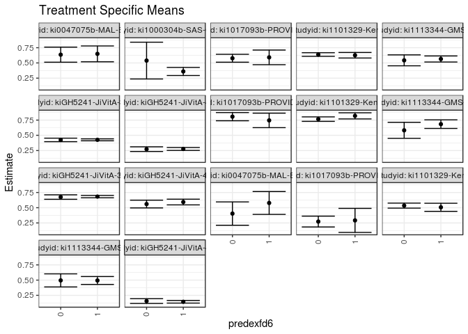

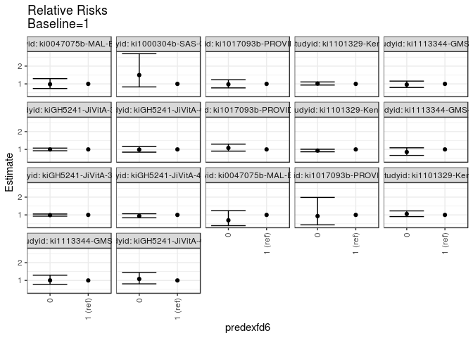

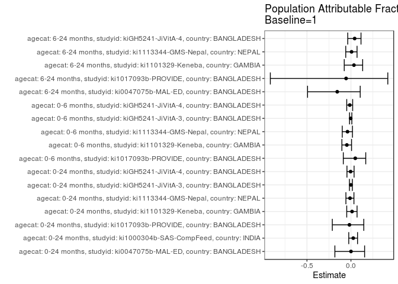

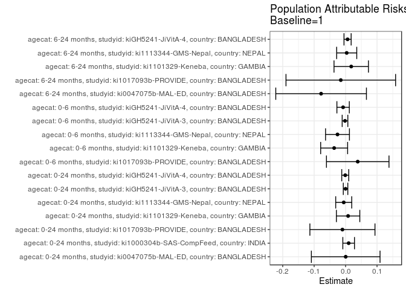

## Results Table

### Parameter: TSM

| agecat | studyid | country | intervention_level | baseline_level | estimate | ci_lower | ci_upper |
| --- | --- | --- | --- | --- | --- | --- | --- |
| 0-24 months | ki0047075b-MAL-ED | BANGLADESH | 1 | NA | 0.6487685 | 0.5185790 | 0.7789581 |
| 0-24 months | ki0047075b-MAL-ED | BANGLADESH | 0 | NA | 0.6355126 | 0.5117562 | 0.7592689 |
| 0-24 months | ki1000304b-SAS-CompFeed | INDIA | 1 | NA | 0.3600000 | 0.2937351 | 0.4262649 |
| 0-24 months | ki1000304b-SAS-CompFeed | INDIA | 0 | NA | 0.5384615 | 0.2364546 | 0.8404685 |
| 0-24 months | ki1017093b-PROVIDE | BANGLADESH | 1 | NA | 0.5912170 | 0.4711072 | 0.7113268 |
| 0-24 months | ki1017093b-PROVIDE | BANGLADESH | 0 | NA | 0.5768277 | 0.5119043 | 0.6417512 |
| 0-24 months | ki1101329-Keneba | GAMBIA | 1 | NA | 0.6262191 | 0.5807867 | 0.6716515 |
| 0-24 months | ki1101329-Keneba | GAMBIA | 0 | NA | 0.6376864 | 0.6079185 | 0.6674543 |
| 0-24 months | ki1113344-GMS-Nepal | NEPAL | 1 | NA | 0.5648625 | 0.5151078 | 0.6146171 |
| 0-24 months | ki1113344-GMS-Nepal | NEPAL | 0 | NA | 0.5424717 | 0.4528553 | 0.6320882 |
| 0-24 months | kiGH5241-JiVitA-3 | BANGLADESH | 1 | NA | 0.4260953 | 0.4100980 | 0.4420927 |
| 0-24 months | kiGH5241-JiVitA-3 | BANGLADESH | 0 | NA | 0.4245269 | 0.3956268 | 0.4534269 |
| 0-24 months | kiGH5241-JiVitA-4 | BANGLADESH | 1 | NA | 0.2759428 | 0.2520322 | 0.2998534 |
| 0-24 months | kiGH5241-JiVitA-4 | BANGLADESH | 0 | NA | 0.2729085 | 0.2347194 | 0.3110976 |
| 0-6 months | ki1017093b-PROVIDE | BANGLADESH | 1 | NA | 0.7451819 | 0.6262559 | 0.8641078 |
| 0-6 months | ki1017093b-PROVIDE | BANGLADESH | 0 | NA | 0.8065160 | 0.7391563 | 0.8738757 |
| 0-6 months | ki1101329-Keneba | GAMBIA | 1 | NA | 0.8195814 | 0.7692465 | 0.8699163 |
| 0-6 months | ki1101329-Keneba | GAMBIA | 0 | NA | 0.7662033 | 0.7293337 | 0.8030730 |
| 0-6 months | ki1113344-GMS-Nepal | NEPAL | 1 | NA | 0.6836428 | 0.6130669 | 0.7542187 |
| 0-6 months | ki1113344-GMS-Nepal | NEPAL | 0 | NA | 0.5820380 | 0.4507338 | 0.7133421 |
| 0-6 months | kiGH5241-JiVitA-3 | BANGLADESH | 1 | NA | 0.6826530 | 0.6634219 | 0.7018841 |
| 0-6 months | kiGH5241-JiVitA-3 | BANGLADESH | 0 | NA | 0.6749354 | 0.6383904 | 0.7114803 |
| 0-6 months | kiGH5241-JiVitA-4 | BANGLADESH | 1 | NA | 0.5934481 | 0.5464057 | 0.6404906 |
| 0-6 months | kiGH5241-JiVitA-4 | BANGLADESH | 0 | NA | 0.5602794 | 0.4966702 | 0.6238886 |
| 6-24 months | ki0047075b-MAL-ED | BANGLADESH | 1 | NA | 0.5778977 | 0.3902409 | 0.7655544 |
| 6-24 months | ki0047075b-MAL-ED | BANGLADESH | 0 | NA | 0.4036330 | 0.2118681 | 0.5953980 |
| 6-24 months | ki1017093b-PROVIDE | BANGLADESH | 1 | NA | 0.2916667 | 0.0943448 | 0.4889886 |
| 6-24 months | ki1017093b-PROVIDE | BANGLADESH | 0 | NA | 0.2727273 | 0.1836941 | 0.3617604 |
| 6-24 months | ki1101329-Keneba | GAMBIA | 1 | NA | 0.5069334 | 0.4404624 | 0.5734043 |
| 6-24 months | ki1101329-Keneba | GAMBIA | 0 | NA | 0.5344383 | 0.4934262 | 0.5754503 |
| 6-24 months | ki1113344-GMS-Nepal | NEPAL | 1 | NA | 0.4936965 | 0.4286508 | 0.5587422 |
| 6-24 months | ki1113344-GMS-Nepal | NEPAL | 0 | NA | 0.4954043 | 0.3879591 | 0.6028496 |
| 6-24 months | kiGH5241-JiVitA-4 | BANGLADESH | 1 | NA | 0.1442515 | 0.1227953 | 0.1657076 |
| 6-24 months | kiGH5241-JiVitA-4 | BANGLADESH | 0 | NA | 0.1559010 | 0.1168207 | 0.1949813 |

### Parameter: E(Y)

| agecat | studyid | country | intervention_level | baseline_level | estimate | ci_lower | ci_upper |
| --- | --- | --- | --- | --- | --- | --- | --- |
| 0-24 months | ki0047075b-MAL-ED | BANGLADESH | NA | NA | 0.6491228 | 0.5591034 | 0.7391422 |
| 0-24 months | ki1000304b-SAS-CompFeed | INDIA | NA | NA | 0.3697479 | 0.3045176 | 0.4349782 |
| 0-24 months | ki1017093b-PROVIDE | BANGLADESH | NA | NA | 0.5811688 | 0.5245443 | 0.6377934 |
| 0-24 months | ki1101329-Keneba | GAMBIA | NA | NA | 0.6342072 | 0.6090524 | 0.6593621 |
| 0-24 months | ki1113344-GMS-Nepal | NEPAL | NA | NA | 0.5589226 | 0.5151400 | 0.6027051 |
| 0-24 months | kiGH5241-JiVitA-3 | BANGLADESH | NA | NA | 0.4259832 | 0.4115786 | 0.4403878 |
| 0-24 months | kiGH5241-JiVitA-4 | BANGLADESH | NA | NA | 0.2748506 | 0.2539041 | 0.2957971 |
| 0-6 months | ki1017093b-PROVIDE | BANGLADESH | NA | NA | 0.7837838 | 0.7252863 | 0.8422812 |
| 0-6 months | ki1101329-Keneba | GAMBIA | NA | NA | 0.7831858 | 0.7527627 | 0.8136090 |
| 0-6 months | ki1113344-GMS-Nepal | NEPAL | NA | NA | 0.6578947 | 0.5956613 | 0.7201282 |
| 0-6 months | kiGH5241-JiVitA-3 | BANGLADESH | NA | NA | 0.6807910 | 0.6636189 | 0.6979630 |
| 0-6 months | kiGH5241-JiVitA-4 | BANGLADESH | NA | NA | 0.5855513 | 0.5434121 | 0.6276905 |
| 6-24 months | ki0047075b-MAL-ED | BANGLADESH | NA | NA | 0.5000000 | 0.3630175 | 0.6369825 |
| 6-24 months | ki1017093b-PROVIDE | BANGLADESH | NA | NA | 0.2764228 | 0.1950773 | 0.3577682 |
| 6-24 months | ki1101329-Keneba | GAMBIA | NA | NA | 0.5248918 | 0.4904236 | 0.5593599 |
| 6-24 months | ki1113344-GMS-Nepal | NEPAL | NA | NA | 0.4972678 | 0.4417121 | 0.5528234 |
| 6-24 months | kiGH5241-JiVitA-4 | BANGLADESH | NA | NA | 0.1505703 | 0.1316510 | 0.1694897 |

### Parameter: RR

| agecat | studyid | country | intervention_level | baseline_level | estimate | ci_lower | ci_upper |
| --- | --- | --- | --- | --- | --- | --- | --- |
| 0-24 months | ki0047075b-MAL-ED | BANGLADESH | 1 | 1 | 1.0000000 | 1.0000000 | 1.000000 |
| 0-24 months | ki0047075b-MAL-ED | BANGLADESH | 0 | 1 | 0.9795675 | 0.7408215 | 1.295255 |
| 0-24 months | ki1000304b-SAS-CompFeed | INDIA | 1 | 1 | 1.0000000 | 1.0000000 | 1.000000 |
| 0-24 months | ki1000304b-SAS-CompFeed | INDIA | 0 | 1 | 1.4957265 | 0.8288715 | 2.699089 |
| 0-24 months | ki1017093b-PROVIDE | BANGLADESH | 1 | 1 | 1.0000000 | 1.0000000 | 1.000000 |
| 0-24 months | ki1017093b-PROVIDE | BANGLADESH | 0 | 1 | 0.9756616 | 0.7731685 | 1.231188 |
| 0-24 months | ki1101329-Keneba | GAMBIA | 1 | 1 | 1.0000000 | 1.0000000 | 1.000000 |
| 0-24 months | ki1101329-Keneba | GAMBIA | 0 | 1 | 1.0183120 | 0.9349952 | 1.109053 |
| 0-24 months | ki1113344-GMS-Nepal | NEPAL | 1 | 1 | 1.0000000 | 1.0000000 | 1.000000 |
| 0-24 months | ki1113344-GMS-Nepal | NEPAL | 0 | 1 | 0.9603607 | 0.7975770 | 1.156368 |
| 0-24 months | kiGH5241-JiVitA-3 | BANGLADESH | 1 | 1 | 1.0000000 | 1.0000000 | 1.000000 |
| 0-24 months | kiGH5241-JiVitA-3 | BANGLADESH | 0 | 1 | 0.9963190 | 0.9240410 | 1.074250 |
| 0-24 months | kiGH5241-JiVitA-4 | BANGLADESH | 1 | 1 | 1.0000000 | 1.0000000 | 1.000000 |
| 0-24 months | kiGH5241-JiVitA-4 | BANGLADESH | 0 | 1 | 0.9890038 | 0.8451969 | 1.157279 |
| 0-6 months | ki1017093b-PROVIDE | BANGLADESH | 1 | 1 | 1.0000000 | 1.0000000 | 1.000000 |
| 0-6 months | ki1017093b-PROVIDE | BANGLADESH | 0 | 1 | 1.0823076 | 0.9033360 | 1.296738 |
| 0-6 months | ki1101329-Keneba | GAMBIA | 1 | 1 | 1.0000000 | 1.0000000 | 1.000000 |
| 0-6 months | ki1101329-Keneba | GAMBIA | 0 | 1 | 0.9348716 | 0.8663170 | 1.008851 |
| 0-6 months | ki1113344-GMS-Nepal | NEPAL | 1 | 1 | 1.0000000 | 1.0000000 | 1.000000 |
| 0-6 months | ki1113344-GMS-Nepal | NEPAL | 0 | 1 | 0.8513773 | 0.6642363 | 1.091243 |
| 0-6 months | kiGH5241-JiVitA-3 | BANGLADESH | 1 | 1 | 1.0000000 | 1.0000000 | 1.000000 |
| 0-6 months | kiGH5241-JiVitA-3 | BANGLADESH | 0 | 1 | 0.9886947 | 0.9306957 | 1.050308 |
| 0-6 months | kiGH5241-JiVitA-4 | BANGLADESH | 1 | 1 | 1.0000000 | 1.0000000 | 1.000000 |
| 0-6 months | kiGH5241-JiVitA-4 | BANGLADESH | 0 | 1 | 0.9441085 | 0.8375860 | 1.064178 |
| 6-24 months | ki0047075b-MAL-ED | BANGLADESH | 1 | 1 | 1.0000000 | 1.0000000 | 1.000000 |
| 6-24 months | ki0047075b-MAL-ED | BANGLADESH | 0 | 1 | 0.6984507 | 0.3936021 | 1.239407 |
| 6-24 months | ki1017093b-PROVIDE | BANGLADESH | 1 | 1 | 1.0000000 | 1.0000000 | 1.000000 |
| 6-24 months | ki1017093b-PROVIDE | BANGLADESH | 0 | 1 | 0.9350649 | 0.4411401 | 1.982015 |
| 6-24 months | ki1101329-Keneba | GAMBIA | 1 | 1 | 1.0000000 | 1.0000000 | 1.000000 |
| 6-24 months | ki1101329-Keneba | GAMBIA | 0 | 1 | 1.0542574 | 0.9069726 | 1.225460 |
| 6-24 months | ki1113344-GMS-Nepal | NEPAL | 1 | 1 | 1.0000000 | 1.0000000 | 1.000000 |
| 6-24 months | ki1113344-GMS-Nepal | NEPAL | 0 | 1 | 1.0034592 | 0.7785272 | 1.293379 |
| 6-24 months | kiGH5241-JiVitA-4 | BANGLADESH | 1 | 1 | 1.0000000 | 1.0000000 | 1.000000 |
| 6-24 months | kiGH5241-JiVitA-4 | BANGLADESH | 0 | 1 | 1.0807584 | 0.8074132 | 1.446643 |

### Parameter: PAR

| agecat | studyid | country | intervention_level | baseline_level | estimate | ci_lower | ci_upper |
| --- | --- | --- | --- | --- | --- | --- | --- |
| 0-24 months | ki0047075b-MAL-ED | BANGLADESH | 1 | NA | 0.0003543 | -0.1088461 | 0.1095547 |
| 0-24 months | ki1000304b-SAS-CompFeed | INDIA | 1 | NA | 0.0097479 | -0.0087899 | 0.0282857 |
| 0-24 months | ki1017093b-PROVIDE | BANGLADESH | 1 | NA | -0.0100482 | -0.1135643 | 0.0934679 |
| 0-24 months | ki1101329-Keneba | GAMBIA | 1 | NA | 0.0079882 | -0.0292199 | 0.0451962 |
| 0-24 months | ki1113344-GMS-Nepal | NEPAL | 1 | NA | -0.0059399 | -0.0314280 | 0.0195481 |
| 0-24 months | kiGH5241-JiVitA-3 | BANGLADESH | 1 | NA | -0.0001121 | -0.0072782 | 0.0070540 |
| 0-24 months | kiGH5241-JiVitA-4 | BANGLADESH | 1 | NA | -0.0010922 | -0.0122310 | 0.0100467 |
| 0-6 months | ki1017093b-PROVIDE | BANGLADESH | 1 | NA | 0.0386019 | -0.0608699 | 0.1380737 |
| 0-6 months | ki1101329-Keneba | GAMBIA | 1 | NA | -0.0363956 | -0.0792762 | 0.0064851 |
| 0-6 months | ki1113344-GMS-Nepal | NEPAL | 1 | NA | -0.0257481 | -0.0637394 | 0.0122432 |
| 0-6 months | kiGH5241-JiVitA-3 | BANGLADESH | 1 | NA | -0.0018620 | -0.0108531 | 0.0071290 |
| 0-6 months | kiGH5241-JiVitA-4 | BANGLADESH | 1 | NA | -0.0078968 | -0.0276552 | 0.0118616 |
| 6-24 months | ki0047075b-MAL-ED | BANGLADESH | 1 | NA | -0.0778977 | -0.2220723 | 0.0662769 |
| 6-24 months | ki1017093b-PROVIDE | BANGLADESH | 1 | NA | -0.0152439 | -0.1895523 | 0.1590645 |
| 6-24 months | ki1101329-Keneba | GAMBIA | 1 | NA | 0.0179584 | -0.0368077 | 0.0727245 |
| 6-24 months | ki1113344-GMS-Nepal | NEPAL | 1 | NA | 0.0035712 | -0.0283631 | 0.0355056 |
| 6-24 months | kiGH5241-JiVitA-4 | BANGLADESH | 1 | NA | 0.0063189 | -0.0050545 | 0.0176922 |

### Parameter: PAF

| agecat | studyid | country | intervention_level | baseline_level | estimate | ci_lower | ci_upper |
| --- | --- | --- | --- | --- | --- | --- | --- |
| 0-24 months | ki0047075b-MAL-ED | BANGLADESH | 1 | NA | 0.0005458 | -0.1826548 | 0.1553674 |
| 0-24 months | ki1000304b-SAS-CompFeed | INDIA | 1 | NA | 0.0263636 | -0.0248925 | 0.0750564 |
| 0-24 months | ki1017093b-PROVIDE | BANGLADESH | 1 | NA | -0.0172896 | -0.2118744 | 0.1460516 |
| 0-24 months | ki1101329-Keneba | GAMBIA | 1 | NA | 0.0125955 | -0.0478666 | 0.0695689 |
| 0-24 months | ki1113344-GMS-Nepal | NEPAL | 1 | NA | -0.0106274 | -0.0573175 | 0.0340009 |
| 0-24 months | kiGH5241-JiVitA-3 | BANGLADESH | 1 | NA | -0.0002632 | -0.0172281 | 0.0164187 |
| 0-24 months | kiGH5241-JiVitA-4 | BANGLADESH | 1 | NA | -0.0039736 | -0.0453247 | 0.0357416 |
| 0-6 months | ki1017093b-PROVIDE | BANGLADESH | 1 | NA | 0.0492507 | -0.0868808 | 0.1683318 |
| 0-6 months | ki1101329-Keneba | GAMBIA | 1 | NA | -0.0464712 | -0.1028796 | 0.0070522 |
| 0-6 months | ki1113344-GMS-Nepal | NEPAL | 1 | NA | -0.0391371 | -0.0989203 | 0.0173938 |
| 0-6 months | kiGH5241-JiVitA-3 | BANGLADESH | 1 | NA | -0.0027351 | -0.0160307 | 0.0103866 |
| 0-6 months | kiGH5241-JiVitA-4 | BANGLADESH | 1 | NA | -0.0134861 | -0.0477834 | 0.0196886 |
| 6-24 months | ki0047075b-MAL-ED | BANGLADESH | 1 | NA | -0.1557953 | -0.4932675 | 0.1054095 |
| 6-24 months | ki1017093b-PROVIDE | BANGLADESH | 1 | NA | -0.0551471 | -0.9164156 | 0.4190533 |
| 6-24 months | ki1101329-Keneba | GAMBIA | 1 | NA | 0.0342136 | -0.0761489 | 0.1332580 |
| 6-24 months | ki1113344-GMS-Nepal | NEPAL | 1 | NA | 0.0071817 | -0.0591959 | 0.0693996 |
| 6-24 months | kiGH5241-JiVitA-4 | BANGLADESH | 1 | NA | 0.0419662 | -0.0364686 | 0.1144654 |